# Recitation - Week 4

## Exercise 1.

Problem: biologists were interested in whether worker size varies significantly among colonies across the landscape.

1. If the population mean (mu) for bumble bee forager size (ITS) is 3.81, do you think your sample is representative of the whole population? In other words, are the population and sample means similar? If not, is your sample greater or less than the population mean?
2. Are the sample means for foraging worker size for colony 41 and colony 43 different from each other? If not, which colony has greater bumble bee worker size (report p-value)? Repeat question 2 for colony 32 and colony 2.
3. Calculate the mean, standard deviation, standard error, and confidence intervals for forager size for each colony, except Colony 22. [Hint: dplyr might be good here]
4. Create three barplots for mean body size (ITS) for each colony (excluding colony 22) with error bars representing (i) standard deviation, (ii) standard error and (iii) 95% confidence intervals. [HINT: use arrows() function for creating error bars]

```r
bee<-read.csv("BeeNectar.csv")
head(bee)
```

|  | Colony | BeeID | Pollen | ITS | Nectar |
| --- | --- | --- | --- | --- | --- |
| 1 | 57 | B91 | 0.00000 | 4.03 | 0.00027 |
| 2 | 41 | 838E52010B000000 | 0.00153 | 2.87 | 0.00033 |
| 3 | 41 | 798C52010B000000 | 0.02089 | 3.19 | 0.00035 |
| 4 | 57 | B58 | 0.00034 | 3.07 | 0.00063 |
| 5 | 58 | G49 | 0.00000 | 3.42 | 0.00065 |
| 6 | 32 | R24 | 0.02855 | 3.86 | 0.00114 |

```r
m1<-with(bee, t.test(ITS, mu=3.81))
m1
```

```
    One Sample t-test

data:  ITS
t = 1.7083, df = 523, p-value = 0.08817
alternative hypothesis: true mean is not equal to 3.81
95 percent confidence interval:
 3.805473 3.874909
sample estimates:
mean of x
 3.840191
```

```r
m2<-with(bee, t.test(ITS, mu=3.81, alternative="greater")) # sample mean is greater than population mean.
m2
```

```
    One Sample t-test

data:  ITS
t = 1.7083, df = 523, p-value = 0.04408
alternative hypothesis: true mean is greater than 3.81
95 percent confidence interval:
 3.81107     Inf
sample estimates:
mean of x
 3.840191
```

```r
m3<-with(bee, t.test(ITS, mu=3.81, alternative="less"))
m3
```

```
    One Sample t-test

data:  ITS
t = 1.7083, df = 523, p-value = 0.9559
alternative hypothesis: true mean is less than 3.81
95 percent confidence interval:
     -Inf 3.869311
sample estimates:
mean of x
 3.840191
```

```r
m4<-t.test(subset(bee, Colony=="41")$ITS, subset(bee, Colony=="43")$ITS)
m4
```

```
    Welch Two Sample t-test

data:  subset(bee, Colony == "41")$ITS and subset(bee, Colony == "43")$ITS
t = -0.84498, df = 146.99, p-value = 0.3995
alternative hypothesis: true difference in means is not equal to 0
95 percent confidence interval:
 -0.22351919  0.08962667
sample estimates:
mean of x mean of y
 3.708642  3.775588
```

```r
m5<-t.test(subset(bee, Colony=="32")$ITS, subset(bee, Colony=="2")$ITS, alternative="less")
m5
```

```
    Welch Two Sample t-test

data:  subset(bee, Colony == "32")$ITS and subset(bee, Colony == "2")$ITS
t = 2.9602, df = 96.502, p-value = 0.9981
alternative hypothesis: true difference in means is less than 0
95 percent confidence interval:
      -Inf 0.2844462
sample estimates:
mean of x mean of y
 4.078667  3.896452
```

```r
library(dplyr)
table(bee$Colony) # number of observations within each colony. Colony 22 does not have enough
```

```
  2  22  32  35  41  43  57  58
 63   1  45  62  81  68 169  36
```

```r
# Solution 1
bee.m22<-subset(bee, Colony!="22")
bee.m22 %>% group_by(Colony) %>% summarise(mean=mean(ITS, na.rm=T),
                                       sd=sd(ITS, na.rm=T),
                                       se=sd(ITS, na.rm=T)/sqrt(n()),
                                       CI.upper=t.test(ITS)$conf.int[1],
                                       CI.lower=t.test(ITS)$conf.int[2])
```

| Colony | mean | sd | se | CI.upper | CI.lower |
| --- | --- | --- | --- | --- | --- |
| 2 | 3.896452 | 0.3195032 | 0.04025362 | 3.815313 | 3.977590 |
| 32 | 4.078667 | 0.3105098 | 0.04628807 | 3.985379 | 4.171954 |
| 35 | 3.846290 | 0.3239320 | 0.04113940 | 3.764027 | 3.928554 |
| 41 | 3.708642 | 0.5277186 | 0.05863540 | 3.591954 | 3.825330 |
| 43 | 3.775588 | 0.4393733 | 0.05328184 | 3.669237 | 3.881939 |
| 57 | 3.821243 | 0.3598201 | 0.02767847 | 3.766600 | 3.875885 |
| 58 | 3.950278 | 0.4382269 | 0.07303781 | 3.802003 | 4.098552 |

```r
#Solution 2
sums<-bee %>% filter(Colony!="22") %>% group_by(Colony) %>% summarise(mean=mean(ITS),
                                       sd=sd(ITS),
                                        se=sd(ITS)/sqrt(n()),
                                       CI.upper=t.test(ITS)$conf.int[1],
                                       CI.lower=t.test(ITS)$conf.int[2])
sums
```

| Colony | mean | sd | se | CI.upper | CI.lower |
| --- | --- | --- | --- | --- | --- |
| 2 | NA | NA | NA | 3.815313 | 3.977590 |
| 32 | 4.078667 | 0.3105098 | 0.04628807 | 3.985379 | 4.171954 |
| 35 | 3.846290 | 0.3239320 | 0.04113940 | 3.764027 | 3.928554 |
| 41 | 3.708642 | 0.5277186 | 0.05863540 | 3.591954 | 3.825330 |
| 43 | 3.775588 | 0.4393733 | 0.05328184 | 3.669237 | 3.881939 |
| 57 | 3.821243 | 0.3598201 | 0.02767847 | 3.766600 | 3.875885 |
| 58 | 3.950278 | 0.4382269 | 0.07303781 | 3.802003 | 4.098552 |

```r
par(mfrow=c(1,3))
barCenters<-with(sums, barplot(mean, names.arg=Colony, ylim=c(0,5)))
arrows(barCenters, sums$mean-sums$sd, barCenters, sums$mean+sums$sd, angle=90, code=3)
```

```r
barCenters<-with(sums, barplot(mean, names.arg=Colony, ylim=c(0,5)))
arrows(barCenters, sums$mean-sums$se, barCenters, sums$mean+sums$se, angle=90, code=3)
```

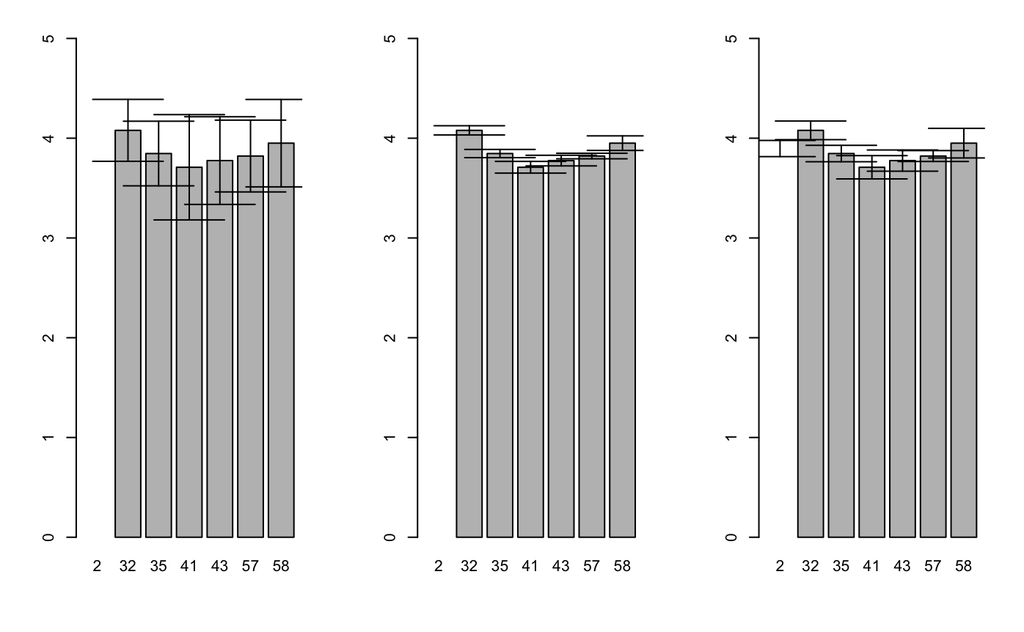

```r
barCenters<-with(sums, barplot(mean, names.arg=Colony, ylim=c(0,5)))
arrows(barCenters, sums$CI.upper, barCenters, sums$CI.lower, angle=90, code=3)
```

## Exercise 2.

Problem: biologists were interested in whether introduced brook trout to affects the survival of chinook salmon.

1. Does the presence or absence of introduced trout affect the proportion of chinook salmon surviving?
2. Create three barplot for mean proportion surviving for both treatments with error bars representing (i) standard deviation, (ii) standard error and (iii) 95% confidence intervals.

```r
salmon<-read.csv("BrookTrout.csv")
head(salmon)
```

|  | troutTreatment | nReleased | nSurvivors | proportionSurvived |
| --- | --- | --- | --- | --- |
| 1 | present | 820 | 166 | 0.202 |
| 2 | absent | 467 | 180 | 0.385 |
| 3 | present | 960 | 136 | 0.142 |
| 4 | present | 700 | 153 | 0.219 |
| 5 | absent | 959 | 178 | 0.186 |
| 6 | present | 545 | 103 | 0.189 |

```r
salmon.t<-with(salmon, t.test(proportionSurvived ~ troutTreatment))
salmon.t
```

```
    Welch Two Sample t-test

data:  proportionSurvived by troutTreatment
t = 0.93148, df = 5.8165, p-value = 0.3886
alternative hypothesis: true difference in means is not equal to 0
95 percent confidence interval:
 -0.06753173  0.14953173
sample estimates:
 mean in group absent mean in group present
            0.2351667             0.1941667
```

```r
salmon.stats<-salmon %>% group_by(troutTreatment) %>% summarise(mean=mean(proportionSurvived),
                                                sd=sd(proportionSurvived),
                                                se=sd(proportionSurvived)/sqrt(n()),
                                                CI.upper=t.test(proportionSurvived)$conf.int[1],
                                                CI.lower=t.test(proportionSurvived)$conf.int[2])
salmon.stats
```

| troutTreatment | mean | sd | se | CI.upper | CI.lower |
| --- | --- | --- | --- | --- | --- |
| absent | 0.2351667 | 0.10364056 | 0.04231108 | 0.1264026 | 0.3439308 |
| present | 0.1941667 | 0.02971476 | 0.01213100 | 0.1629829 | 0.2253504 |

```r
par(mfrow=c(1,3))
barCenters<-with(salmon.stats, barplot(mean, names.arg=troutTreatment, ylim=c(0,1), ylab="Proportion surviving"))
arrows(barCenters, salmon.stats$mean-salmon.stats$sd, barCenters, salmon.stats$mean+salmon.stats$sd, angle=90, code=3)
```

```r
barCenters<-with(salmon.stats, barplot(mean, names.arg=troutTreatment, ylim=c(0,1),ylab="Proportion surviving"))
arrows(barCenters, salmon.stats$mean-salmon.stats$se, barCenters, salmon.stats$mean+salmon.stats$se, angle=90, code=3)
```

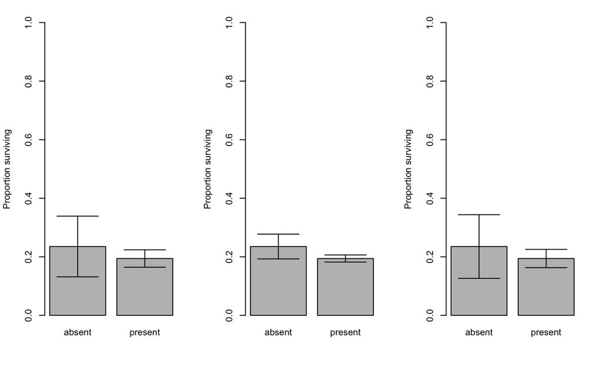

```r
barCenters<-with(salmon.stats, barplot(mean, names.arg=troutTreatment, ylim=c(0,1), ylab="Proportion surviving"))
arrows(barCenters, salmon.stats$CI.upper, barCenters, salmon.stats$CI.lower, angle=90, code=3)
```